# Rough Draft

2024-04-17

Authors: Cameron Stover, Callie Toms, Qidi An, Jack Ohmann

# Introduction

The sport of baseball has long been focused on data and the analysis of numbers. Everything that happens during a game can be quantified, and used to work towards future success. This is especially true over the last 10 years as technology has allowed data to be collected in ways that had never been done before. New stat categories such as Barrels, Hard Hit %, Meatball %, Whiffs, Spin Rate, and OAA all attempt to represent all aspects of baseball as data points. The main purpose of this is for players to hone their skills and focus on areas of needed improvement, as well as for managers and front office members to form the best “on paper” team they can. But what stat categories actually matter? Are there certain skill sets that are more valuable for a player to possess? At the end of the day, it is a player’s job to be able to hit the ball and reach base successfully. There are several approaches to this goal, including power and speed. Are either of these strategies successful? The statistical representations of these approaches are Exit Velocity (how hard the ball is hit) and Sprint Speed (ft/sec), while success is measured by BABIP (batting average on balls in play). These categories can be used to answer important questions about player attributes and success on the field. What is the correlation between speed and BABIP? What is the correlation between power and BABIP?

We anticipate that Exit Velocity will be positively correlated with BABIP, and BABIP will increase with Exit Velocity. Similarly, we anticipate that Sprint Speed will be positively correlated with BABIP, and BABIP will increase as Sprint Speed does.

# Background

The data for this project was collected by Baseball Savant from Major League Baseball games. Baseball Savant is operated by Major League Baseball Advanced Media (MLBAM). Data is pulled every night from the games that occurred that day, representing numerous categories. Data is gathered during the games through the use of high powered cameras and radars which track various metrics. The Baseball Savant website has a customization feature which allows for data sets to be created with any categories of interest. In this case, the categories of Player, Plate Appearances (PA), Batting Average on Balls in Play (BABIP), Average Exit Velocity (Avg EV), and Sprint Speed were used.

The data set includes a row for every MLB player in 2023 with at least 300 plate appearances. A plate appearance is recorded every time a batter goes up to the plate to hit. A cutoff of 300 PA’s was chosen to ensure that the corresponding variables of interest for each player are not just the result of random noise. The data set includes a column for Player, PA, BABIP, Avg EV, and Sprint Speed. BABIP represents a player’s batting average on balls that they hit into the field of play. This ignores any plate appearance that does not result in a ball being put in play. Avg EV measures the average speed in miles per hour (MPH) of the baseball as it comes off the bat. Sprint Speed measures the speed of the players in their fastest one-second window in feet per second. Player is each player’s name in last name, first name format.

We will use several statistical techniques to determine if there is a relationship between exit velocity and BABIP or sprint speed and BABIP.

Data Source:

https://baseballsavant.mlb.com/leaderboard/custom?year=2023&type=batter&filter=&min=300&selections=pa%2Cbabip%2Cexit_velocity_avg%2Csprint_speed&chart=false&x=pa&y=pa&r=no&chartType=beeswarm&sort=sprint_speed&sortDir=desc

# Analysis

### Data

```
## # A tibble: 293 × 6
##    `last_name, first_name`  year    pa babip exit_velocity_avg sprint_speed
##    <chr>                   <dbl> <dbl> <dbl>             <dbl>        <dbl>
##  1 Cabrera, Miguel          2023   370 0.317              89.1         23.1
##  2 Peralta, David           2023   422 0.296              89.3         27
##  3 Blackmon, Charlie        2023   413 0.307              86.4         27.6
##  4 Maldonado, Martín        2023   407 0.26               88.4         23.2
##  5 Solano, Donovan          2023   450 0.366              90.2         25.4
##  6 McCutchen, Andrew        2023   473 0.312              89.6         28.4
##  7 Turner, Justin           2023   626 0.304              89.5         25.2
##  8 Andrus, Elvis            2023   406 0.294              87.5         26.5
##  9 Santana, Carlos          2023   619 0.255              88.8         25.9
## 10 Belt, Brandon            2023   404 0.37               88.7         26.2
## # ℹ 283 more rows
```

The data set contains columns for name, year, PA, BABIP, EV, and Sprint Speed. There are 293 rows in the data, each representing a different player that had at least 300 PA’s in 2023.

```
## # A tibble: 1 × 2
##   Overall_Average_EV Overall_Average_Speed
##                <dbl>                 <dbl>
## 1               89.2                  27.4
```

The overall average exit velocity and speed for the data set is shown in this table.

### Distribution of Data

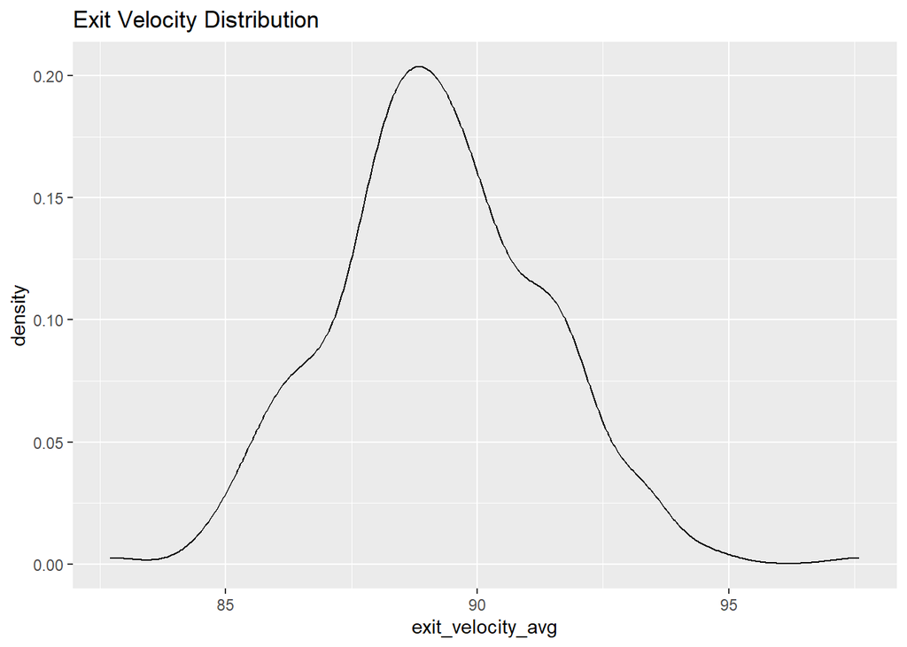

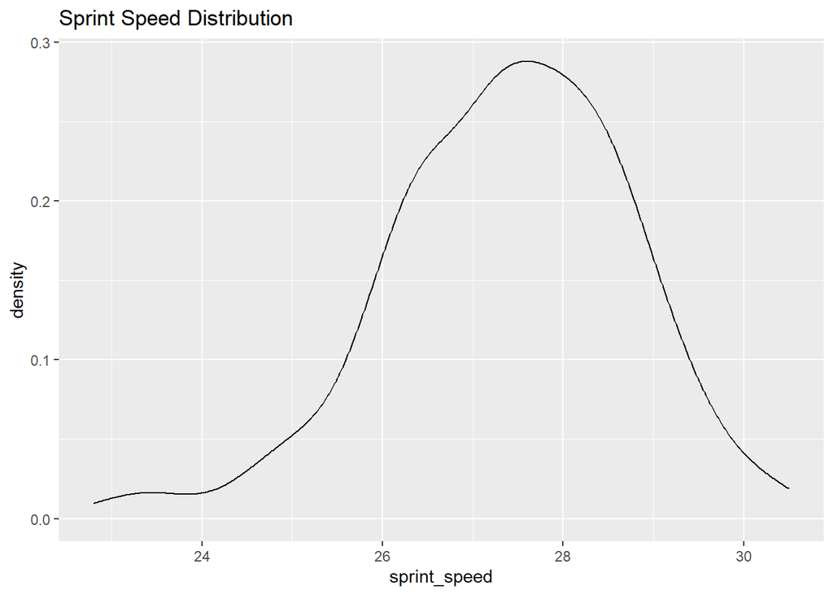

These density graphs represent the distribution of the data. Both exit velocity and sprint speed are bell shaped distributions, and linear regression can be used.

### Residuals

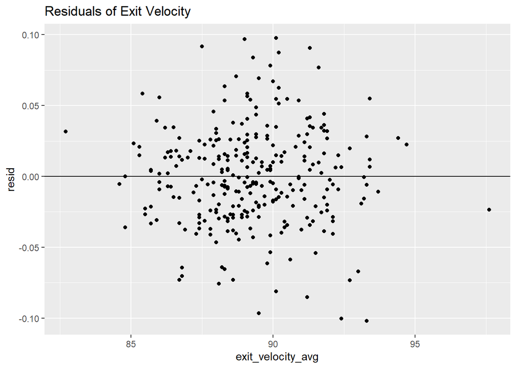

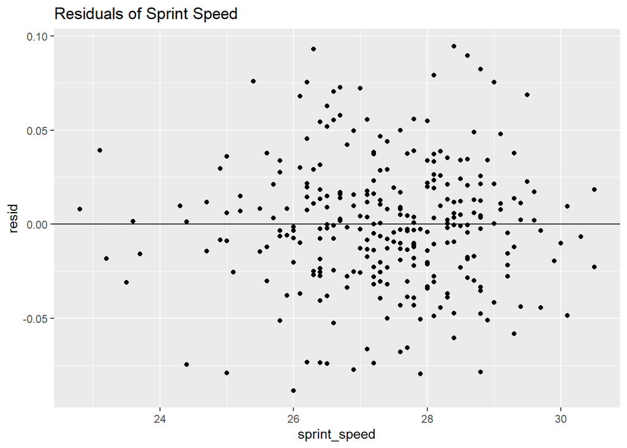

The graphs of the residuals demonstrates that the data satisfies the three assumptions. Linearity is satisfied, as there is not any obvious non-linear pattern in the graph. Normal errors around zero is satisfied as the data tends to stay near the center line. There are some points that stray away from zero, but one side isn’t obviously skewed. Finally, constant variance is satisfied as the data has approximately the same spread as it moves across the plot. There is slight fanning of the data in the sprint speed graph, but not so much as to cause concern.

### Linear Regression

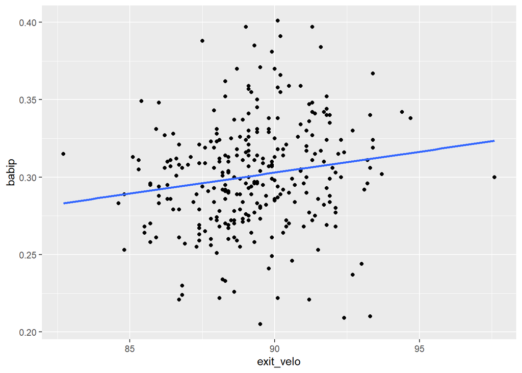

```
##
## Call:
## lm(formula = babip ~ exit_velo)
##
## Coefficients:
## (Intercept)    exit_velo
##    0.059676     0.002703
```

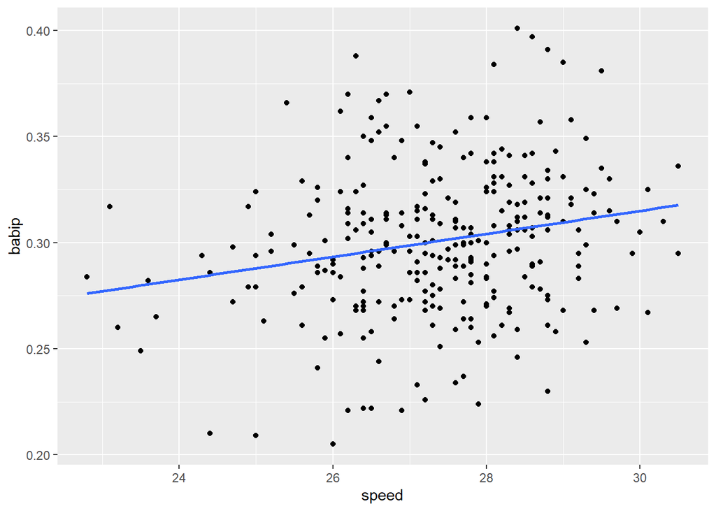

```
##
## Call:
## lm(formula = babip ~ speed)
##
## Coefficients:
## (Intercept)        speed
##    0.152782     0.005407
```

### Confidence Intervals and Hypothesis Tests

#### Exit Velocity

```
## [1] 0.0007965406 0.0046092399
```

```
##
## Call:
## lm(formula = babip ~ exit_velo)
##
## Residuals:
##       Min        1Q    Median        3Q       Max
## -0.101855 -0.022773 -0.001368  0.020768  0.097794
##
## Coefficients:
##              Estimate Std. Error t value Pr(>|t|)
## (Intercept) 0.0596757  0.0864471   0.690  0.49055
## exit_velo   0.0027029  0.0009686   2.791  0.00561 **
## ---
## Signif. codes:  0 '***' 0.001 '**' 0.01 '*' 0.05 '.' 0.1 ' ' 1
##
## Residual standard error: 0.03467 on 291 degrees of freedom
## Multiple R-squared:  0.02606,    Adjusted R-squared:  0.02272
## F-statistic: 7.787 on 1 and 291 DF,  p-value: 0.005609
```

The confidence interval for the slope coefficient from the linear regression of Exit Velocity vs BABIP is shown above. The confidence interval was calculated following the formula: Point Estimate ± Quantile Confidence Score * Standard Error of PE. The sampling distribution for the estimate of the slope is: t(df=n−2). The Quantile Confidence score was calculated from this distribution.

The 95% confidence interval was found to be from .00080 to .0046.

A summary of the linear regression model was also calculated. Statistics of interest include the t-value (2.791) and the p value (.0028). (p value is halved as we are doing a one sided test)

#### Sprint Speed

```r
x = speed
y = babip
C = 0.95
n = nrow(baseball)

r = cor(x, y)
beta_hat_1 = r * sd(y) / sd(x)
se = 0.0009686
moe = qt(C + (1-C)/2, df = n - 2)*se

left = beta_hat_1 - moe
right = beta_hat_1 + moe

c(left, right)
```

```
## [1] 0.003500830 0.007313529
```

```r
summary(speed_model)
```

```
##
## Call:
## lm(formula = babip ~ speed)
##
## Residuals:
##       Min        1Q    Median        3Q       Max
## -0.088369 -0.021672 -0.000427  0.019276  0.094654
##
## Coefficients:
##             Estimate Std. Error t value Pr(>|t|)
## (Intercept) 0.152782   0.040704   3.753 0.000211 ***
## speed       0.005407   0.001485   3.642 0.000320 ***
## ---
## Signif. codes:  0 '***' 0.001 '**' 0.01 '*' 0.05 '.' 0.1 ' ' 1
##
## Residual standard error: 0.03436 on 291 degrees of freedom
## Multiple R-squared:  0.04359,    Adjusted R-squared:  0.04031
## F-statistic: 13.26 on 1 and 291 DF,  p-value: 0.0003201
```

A summary of the linear regression model was also calculated. Statistics of interest include the t-value (3.642) and the p value (.00016). (p value is halved as we are doing a one sided test)

# Discussion

There are some potential short comings of this project that could have affected our results. For example, the ballpark that a player plays a majority of their games at is not considered. Someone could have a very high exit velocity but a low BABIP due to the external conditions they play in. The opposite could be true as well, for example Coors Field in Denver has artificially high batting success due to the elevation of the city. Someone with a low exit velocity could have a higher than expected BABIP.

The motivation of this research project was to determine what traits are most useful for a baseball player to have. The balance between speed and power is a delicate one, with the ideal combination highly debated. From our data, we found that speed and power are both positively related to success (measured by BABIP). A next step would be to conduct multiple regression to determine which one has more of an impact. Although it appears that speed is a larger contributor, we cannot say that definitively when we only used single regression. Furthermore, in future investigations, it would be interesting to use data from more years besides 2023. Do the same results that we found hold when looking at 5 years of data? What about reducing the minimum PA threshold? Other future directions could be to examine other factors that impact BABIP. How does home run rate affect BABIP? How does launch angle or chase rate affect BABIP? Maybe using BABIP to measure success isn’t even the best statistic? There are countless avenues for future research in the game of baseball.

Overall, both exit velocity and sprint speed are positively correlated with BABIP. Hitting the ball harder and running faster both lead to higher success when hitting. These conclusions are supported by the scatter plots depicting the data, the confidence intervals for the slope estimates, and the hypothesis tests conducted on the slope estimates. These different methods all produced the same result of a positive correlation.